# Analásis de coches financiados en Coches.net

#### *by Albert Lanza: https://www.linkedin.com/in/albert-lanza-rio/*

Se han extraído aquellos anuncios con los siguientes atributos:

1. Aquellos que son financiables
2. Extraídos de más nuevo a más antiguo
3. Alrededor del 45% del total del stock disponible a 19/11/2025

Mostrar código Python:

## 0. Carga de librerias, datos y cuántos anuncios hay en el dataset

```python
import json
import numpy as np
import pandas as pd
import geopandas as gpd
import plotly.express as px
import matplotlib.pyplot as plt
```

```python
# Cargar los datos previamente extraídos de su web
# https://www.coches.net/segunda-mano/?MinInstalmentPrice=1&hasInstalment=true?pg=1

df = pd.read_csv('scraping_stock_financ_cochesNet_19112025.csv', low_memory=False)
df = df.dropna(subset=['financing_lender'])

print('TOTAL DE VEHÍCULOS en el dataset extraído:', f"{len(df):,.0f}".replace(',', '.'))
print('Columnas del dataset:', list(df.columns))
```

```
TOTAL DE VEHÍCULOS en el dataset extraído: 29.615
Columnas del dataset: ['id', 'title', 'manufacturer', 'model', 'version', 'year', 'kms', 'cubic_capacity', 'environmental_label', 'doors', 'power', 'seating_capacity', 'consumption_urban', 'consumption_extra_urban', 'consumption_mixed', 'max_speed', 'acceleration', 'tank_capacity_in_liters', 'trunk_…
```

## 1. ¿Qué financieras están en Coches.net y qué cuota de mercado tienen en Coches.net?

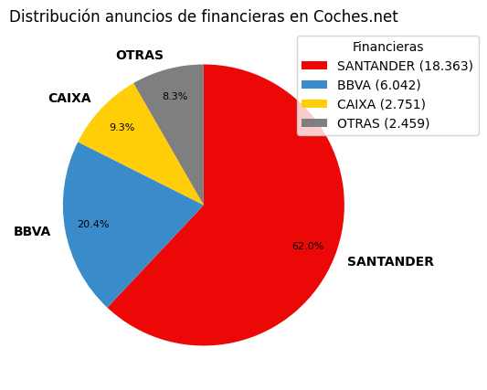

```python
financieras = np.unique(df['financing_lender'])
counts = [len(df[df['financing_lender'] == f]) for f in financieras]

percentages = [c / sum(counts) * 100 for c in counts]

MIN_PERCENTAGE = 3
financieras_filtradas = []
counts_filtrados = []
otras_count = 0

for f, c, p in zip(financieras, counts, percentages):
    if p >= MIN_PERCENTAGE:
        financieras_filtradas.append(f.upper())
        counts_filtrados.append(c)
    else:
        otras_count += c

if otras_count > 0:
    financieras_filtradas.append("OTRAS")
    counts_filtrados.append(otras_count)

orden = np.argsort(counts_filtrados)[::-1]
financieras_filtradas = [financieras_filtradas[i] for i in orden]
counts_filtrados = [counts_filtrados[i] for i in orden]

color_map = {'SANTANDER': '#ED0808', 'BBVA': '#398CC9', 'CAIXA': '#FFCE08'}

plt.figure(figsize=(5, 5))
wedges, texts, autotexts = plt.pie(
    counts_filtrados,
    labels=financieras_filtradas,
    autopct='%1.1f%%',
    counterclock=False,
    startangle=90,
    pctdistance=0.8,
    colors=[color_map.get(f, '#7f7f7f') for f in financieras_filtradas]
)

plt.setp(autotexts, size=8, color="black")
plt.setp(texts, size=10, fontweight='bold')
plt.legend(
    wedges,
    [f"{f} ({format(c, ',').replace(',', '.')})" for f, c in zip(financieras_filtradas, counts_filtrados)],
    title="Financieras",
    loc="upper right",
    bbox_to_anchor=(1.3, 1)
)
plt.title('Distribución anuncios de financieras en Coches.net')
plt.show()
```

## 2. ¿Cómo se distribuyen los anuncios por financiera y cuál es su ticket medio al contado?

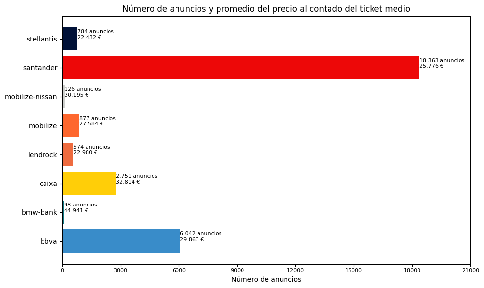

```python
financieras = np.unique(df['financing_lender'])
ads_counts = []
avg_prices = []

for financiera in financieras:
    ads = len(df[df['financing_lender'] == financiera])
    avg_price = df[df['financing_lender'] == financiera]['cash_price'].mean()
    ads_counts.append(ads)
    avg_prices.append(avg_price)

fig, ax = plt.subplots(figsize=(10, 6))

color_map = {'SANTANDER': '#ED0808', 'BBVA': '#398CC9', 'CAIXA': '#FFCE08', 'STELLANTIS': '#001137', 'MOBILIZE-NISSAN': '#CED0CD', 'MOBILIZE': '#FE672E', 'LENDROCK': '#EE6B3F', 'BMW-BANK': '#117C87'}
colors = [color_map.get(f.upper(), '#7f7f7f') for f in financieras]
bars = ax.barh(financieras, ads_counts, color=colors)

for bar, count, price in zip(bars, ads_counts, avg_prices):
    ax.text(bar.get_width(), bar.get_y() + bar.get_height()/2, f"{count:,}".replace(',', '.') + " anuncios\n" + f"{price:,.0f} €".replace(',', '.'), fontsize=8)

ax.set_title("Número de anuncios y promedio del precio al contado del ticket medio")
ax.set_xlabel("Número de anuncios")
plt.xticks(list(range(0, 24000, 3000)), fontsize=8)
plt.tight_layout()
plt.show()
```

## 3. ¿Cuántos concesionarios hay en el dataset y, cada uno, con qué financieras trabaja?

```python
print(f"Hay un total de {df['client_name'].nunique():,.0f} concesionarios en el dataset.\n".replace(',', '.'))
print(f'⬇️ 10 concesionarios aleatorios en número de vehículos anunciados y con qué financieras trabajan:')

counts = df.groupby(['client_name', 'financing_lender']).size().unstack(fill_value=0)
counts['TOTAL'] = counts.sum(axis=1)
counts = counts.sort_values('TOTAL', ascending=False)
counts.sample(10)
```

```
Hay un total de 1.032 concesionarios en el dataset.

⬇️ 10 concesionarios aleatorios en número de vehículos anunciados y con qué financieras trabajan:
```

| financing_lender client_name | bbva | bmw-bank | caixa | lendrock | mobilize | mobilize-nissan | santander | stellantis | TOTAL |
| --- | --- | --- | --- | --- | --- | --- | --- | --- | --- |
| Cars la Sagra | 0 | 0 | 0 | 0 | 0 | 0 | 1 | 0 | 1 |
| Flexicar Sabadell Aeropuerto | 0 | 0 | 0 | 0 | 0 | 0 | 40 | 0 | 40 |
| Total Ocasión: Leganés, Alcalá de Henares, Rivas. | 0 | 0 | 0 | 118 | 0 | 0 | 0 | 0 | 118 |
| AUTOSAE CENTER | 0 | 0 | 0 | 0 | 0 | 12 | 0 | 0 | 12 |
| Ocasionplus GETAFE | 0 | 0 | 0 | 0 | 0 | 0 | 173 | 0 | 173 |
| Seminuevos y Ocasión Lexus Madrid | 0 | 0 | 0 | 0 | 0 | 0 | 41 | 0 | 41 |
| Autos Juanjo | 0 | 0 | 0 | 0 | 0 | 0 | 109 | 0 | 109 |
| Autos Auringis | 0 | 0 | 0 | 0 | 0 | 0 | 0 | 13 | 13 |
| Vázquez de Prada | 7 | 0 | 0 | 3 | 0 | 0 | 0 | 0 | 10 |
| Rivero Motor | 0 | 0 | 0 | 0 | 0 | 0 | 11 | 0 | 11 |

## 4. Gráfico de la distribución de los anuncios por financiera y marca de vehículo

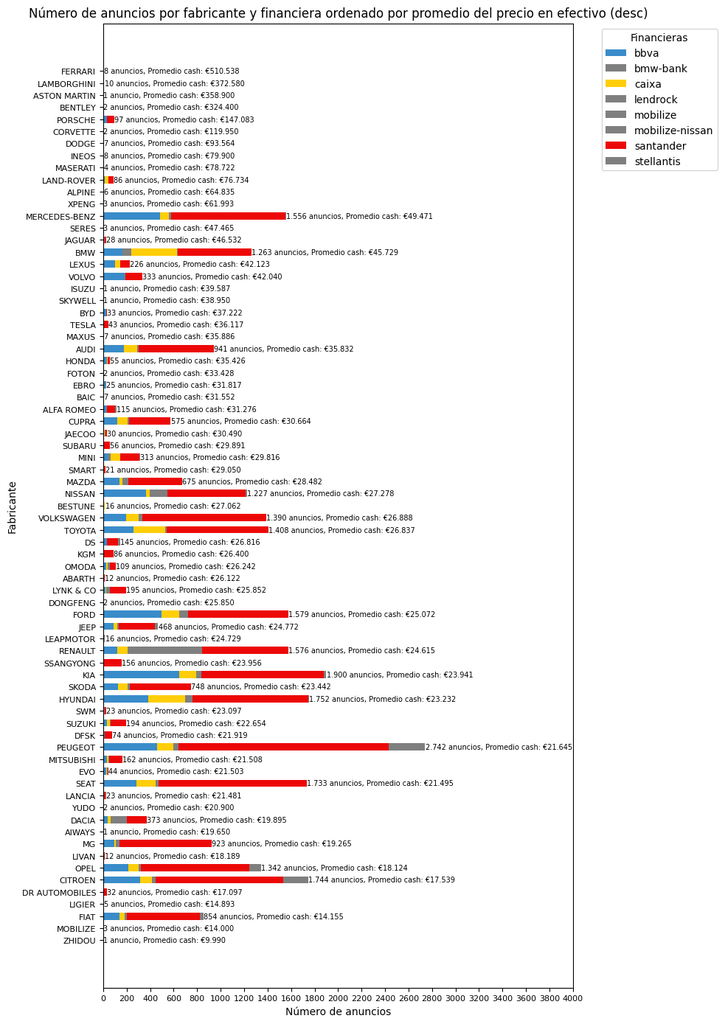

```python
brands = np.unique(df['manufacturer'])
financieras = np.unique(df['financing_lender'])

color_map = {'santander': '#ED0808', 'bbva': '#398CC9', 'caixa': '#FFCE08'}
default_color = '#7f7f7f'

data_matrix = []
for brand in brands:
    row = []
    for f in financieras:
        count = len(df[(df['manufacturer'] == brand) & (df['financing_lender'] == f)])
        row.append(count)
    data_matrix.append(row)

data_matrix = np.array(data_matrix)

avg_prices = [df[df['manufacturer'] == b]['cash_price'].mean() for b in brands]

orden = np.argsort(avg_prices)[::-1]
brands_sorted = [brands[i] for i in orden]
data_matrix_sorted = data_matrix[orden]
avg_prices_sorted = [avg_prices[i] for i in orden]

colors = [color_map.get(f, default_color) for f in financieras]

plt.figure(figsize=(10, 14))
bottom = np.zeros(len(brands_sorted))

for i, f in enumerate(financieras):
    counts = data_matrix_sorted[:, i]
    plt.barh(brands_sorted, counts, left=bottom, color=colors[i], height=0.6, label=f)
    bottom += counts

for i, brand in enumerate(brands_sorted):
    total = np.sum(data_matrix_sorted[i, :])
    avg = avg_prices_sorted[i]
    plt.text(total + 0.5, i, f"{format(total, ',').replace(',', '.')} {'anuncios' if total>1 else 'anuncio'}, Promedio cash: €{format(avg, ',.0f').replace(',', '.')}", va='center', fontsize=7)

plt.xlabel('Número de anuncios')
plt.xticks(list(range(0, 4200, 200)), fontsize=8)
plt.ylabel('Fabricante')
plt.yticks(fontsize=8)
plt.title('Número de anuncios por fabricante y financiera ordenado por promedio del precio en efectivo (desc)')
plt.legend(title='Financieras', bbox_to_anchor=(1.05, 1), loc='upper left')
plt.gca().invert_yaxis()
plt.tight_layout()
plt.show()
```

## 5. Gráfico de España de cuántos anuncios hay por província

```python
gdf = gpd.read_file("provincias_spain.geojson")
count_df = (df.groupby("client_location_province").size().reset_index(name="num_coches"))

merged = gdf.merge(count_df, left_on="Texto", right_on="client_location_province", how="left")
merged["num_coches"] = merged["num_coches"].fillna(0)

geojson_dict = json.loads(merged.to_json())

fig = px.choropleth(
    merged,
    geojson=geojson_dict,
    locations=merged.index,
    color="num_coches",
    hover_name="Texto",
    hover_data={"num_coches": True},
    color_continuous_scale="Viridis"
)

total_coches = f"{len(df):,}".replace(',', '.')
fig.update_geos(fitbounds="locations", visible=False)
fig.update_layout(title=f"Número de coches por provincia. Número de coches en total: {total_coches}")

fig.write_html("mapa_provincias.html", include_plotlyjs='cdn', full_html=True)
fig.show()
```

[interactive chart not shown]

## 6. Promedio del beneficio neto de cada financiera por plazos (84, 96, 108 y 120 meses)

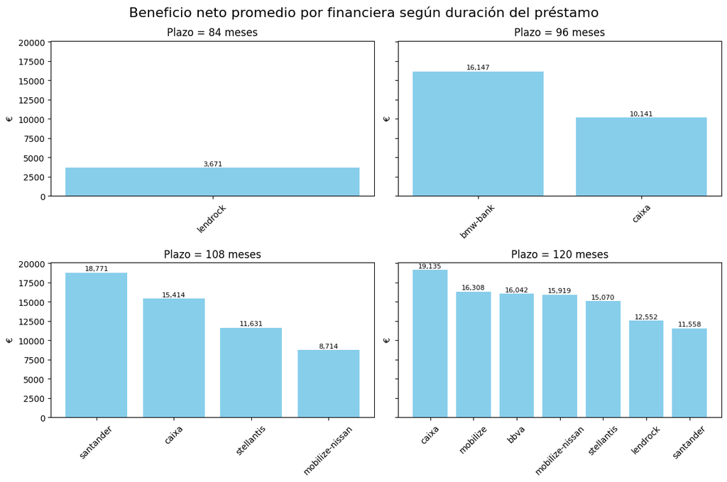

```python
terms_values = sorted(df['financing_terms'].dropna().unique())

df['net_profit'] = df['financing_total_amount_due'] - df['financing_amount_to_finance']

n = len(terms_values)
cols = 2
rows = (n + cols - 1) // cols

fig, axes = plt.subplots(rows, cols, figsize=(12, rows * 4), sharey=True)
axes = axes.flatten()

for i, term in enumerate(terms_values):
    ax = axes[i]
    df_term = df[df['financing_terms'] == term]

    avg_profit = df_term.groupby('financing_lender')['net_profit'].mean().sort_values(ascending=False)
    bars = ax.bar(avg_profit.index, avg_profit.values, color='skyblue')

    for bar in bars:
        height = bar.get_height()
        ax.text(bar.get_x() + bar.get_width() / 2, height + 100, f'{int(height):,}', ha='center', va='bottom', fontsize=8)

    ax.set_title(f'Plazo = {int(term)} meses')
    ax.set_xlabel('')
    ax.set_ylabel('€')
    ax.tick_params(axis='x', rotation=45)

plt.suptitle('Beneficio neto promedio por financiera según duración del préstamo', fontsize=16)
plt.tight_layout()
plt.show()
```

## 7. Promedio del beneficio neto de cada financiera por TIN (5.99, 6.99, 7.50, 7.99, 8.99, 9.99) a 120 meses

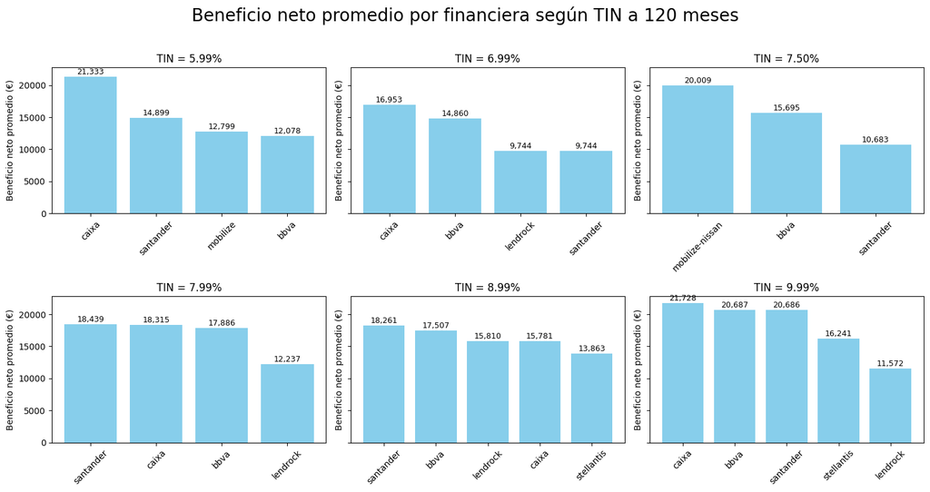

```python
tin_values = [5.99, 6.99, 7.5, 7.99, 8.99, 9.99]

df_120 = df[df['financing_terms'] == 120].copy()
df_120['net_profit'] = df_120['financing_total_amount_due'] - df['financing_amount_to_finance']
df_120 = df_120[df_120['financing_tin'].isin(tin_values)]

n = len(tin_values)
cols = 3
rows = (n + cols - 1) // cols

fig, axes = plt.subplots(rows, cols, figsize=(15, rows * 4), sharey=True)
axes = axes.flatten()

for i, tin in enumerate(tin_values):
    ax = axes[i]
    df_tin = df_120[df_120['financing_tin'] == tin]

    avg_profit = df_tin.groupby('financing_lender')['net_profit'].mean().sort_values(ascending=False)
    bars = ax.bar(avg_profit.index, avg_profit.values, color='skyblue')

    for bar in bars:
        height = bar.get_height()
        ax.text(bar.get_x() + bar.get_width() / 2, height + 100, f'{int(height):,}', ha='center', va='bottom', fontsize=9)

    ax.set_title(f'TIN = {tin:.2f}%')
    ax.set_xlabel('')
    ax.set_ylabel('Beneficio neto promedio (€)')
    ax.tick_params(axis='x', rotation=45)

plt.suptitle('Beneficio neto promedio por financiera según TIN a 120 meses', fontsize=20)
plt.tight_layout(rect=[0, 0, 1, 0.96])
plt.show()
```

## 8. Comparación de vehículo: Audi A1 - Sportback Adrenalin 25 TFSI 70kW 95CV - 2022

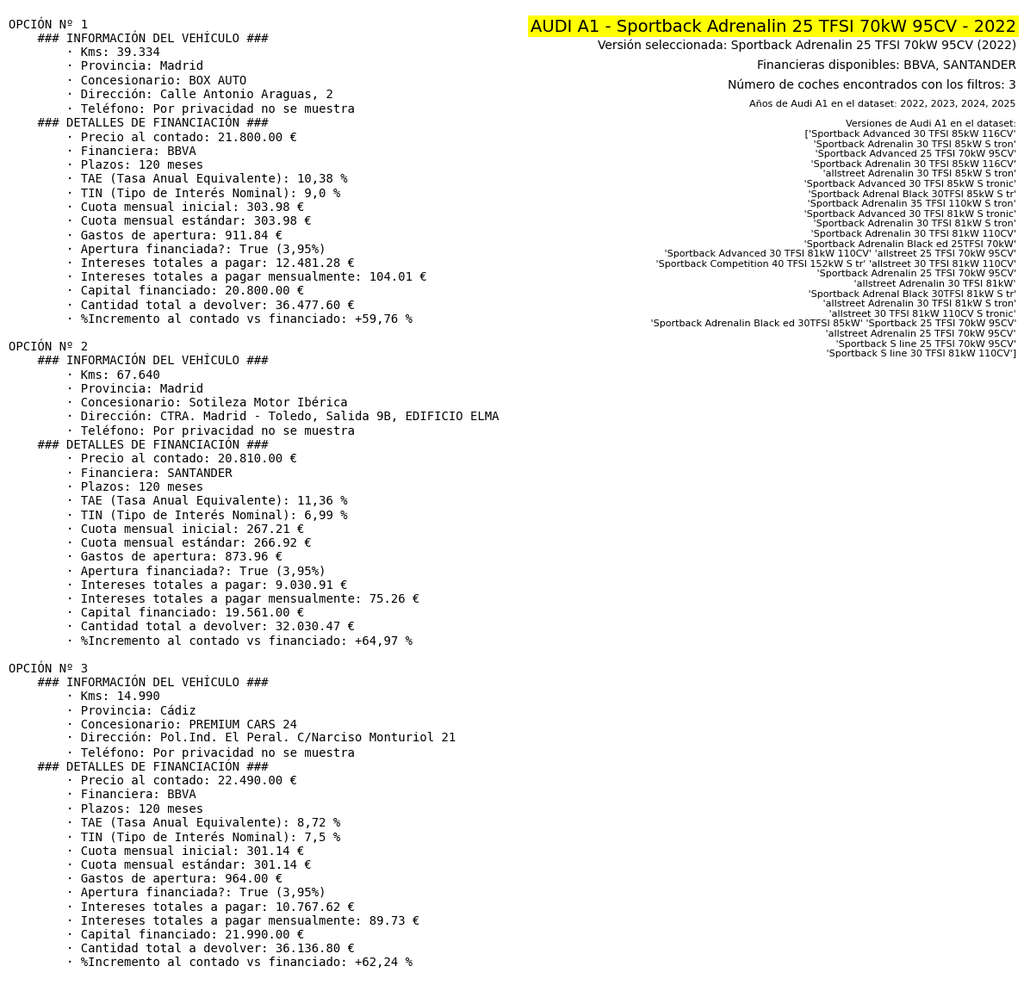

```python
MANUFACTURER = 'AUDI'
MODEL = 'A1'
VERSION = 'Sportback Adrenalin 25 TFSI 70kW 95CV'
YEAR = 2022

df_audis_a1 = df[(df['manufacturer'] == MANUFACTURER) & (df['model'] == MODEL)]

versions_audi_a1 = df_audis_a1['version'].unique()
years_audi_a1 = df_audis_a1['year'].unique()

df_audis_a1_filtered = df_audis_a1[(df_audis_a1['version'] == VERSION) &(df_audis_a1['year'] == YEAR)].reset_index(drop=True)

text_lines = []

for index, car in df_audis_a1_filtered.sort_values('client_location_province', ascending=False).reset_index(drop=True).iterrows():
    text_lines.append(f"OPCIÓN Nº {index+1}")
    text_lines.append(f"    ### INFORMACIÓN DEL VEHÍCULO ###")
    text_lines.append(f"        · Kms: {car['kms']:,.0f}".replace(',', '.'))
    text_lines.append(f"        · Provincia: {car['client_location_province']}")
    text_lines.append(f"        · Concesionario: {car['client_name']}")
    text_lines.append(f"        · Dirección: {car['client_location_address']}")
    text_lines.append(f"        · Teléfono: Por privacidad no se muestra")
    text_lines.append(f"    ### DETALLES DE FINANCIACIÓN ###")
    text_lines.append(f"        · Precio al contado: {car['cash_price']:,.2f} €".replace(',', '.'))
    text_lines.append(f"        · Financiera: {car['financing_lender'].upper()}")
    text_lines.append(f"        · Plazos: {int(car['financing_terms'])} meses")
    text_lines.append(f"        · TAE (Tasa Anual Equivalente): {car['financing_tae']} %".replace('.', ','))
    text_lines.append(f"        · TIN (Tipo de Interés Nominal): {car['financing_tin']} %".replace('.', ','))
    text_lines.append(f"        · Cuota mensual inicial: {car['financing_first_fee']:,.2f} €".replace(',', '.'))
    text_lines.append(f"        · Cuota mensual estándar: {car['financing_fee']:,.2f} €".replace(',', '.'))
    text_lines.append(f"        · Gastos de apertura: {car['financing_opening_expenses']:,.2f} €".replace(',', '.'))
    text_lines.append(f"        · Apertura financiada?: {car['financing_amount_to_finance'] > car['financing_capital']} ({car['financing_opening_percentage']}%)".replace('.', ','))
    text_lines.append(f"        · Intereses totales a pagar: {car['financing_total_interest']:,.2f} €".replace(',', '.'))
    text_lines.append(f"        · Intereses totales a pagar mensualmente: {car['financing_total_interest'] / 120:.2f} €".replace(',', '.'))
    text_lines.append(f"        · Capital financiado: {car['financing_capital']:,.2f} €".replace(',', '.'))
    text_lines.append(f"        · Cantidad total a devolver: {car['financing_total_amount_due']:,.2f} €".replace(',', '.'))
    text_lines.append(f"        · %Incremento al contado vs financiado: +{car['cash_price'] / car['financing_total_amount_due'] * 100:.2f} %".replace('.', ','))

    text_lines.append("")

fig, ax = plt.subplots(figsize=(12, 8))
ax.axis('off')

ax.text(1, 0.95, "AUDI A1 - Sportback Adrenalin 25 TFSI 70kW 95CV - 2022", fontsize=14, va='top', ha='right', bbox=dict(facecolor='yellow', edgecolor='none', pad=2))
ax.text(1, 0.85, "Versión seleccionada: Sportback Adrenalin 25 TFSI 70kW 95CV (2022)", fontsize=10, va='top', ha='right')
ax.text(1, 0.75, f"Financieras disponibles: {', '.join(df_audis_a1_filtered['financing_lender'].unique()).upper()}", fontsize=10, va='top', ha='right')
ax.text(1, 0.65, f"Número de coches encontrados con los filtros: {len(df_audis_a1_filtered)}", fontsize=10, va='top', ha='right')
ax.text(1, 0.55, f"Años de Audi A1 en el dataset: {', '.join(map(str, sorted(years_audi_a1)))}", fontsize=8, va='top', ha='right')
ax.text(1, 0.45, f"Versiones de Audi A1 en el dataset:\n {versions_audi_a1}", fontsize=8, va='top', ha='right')

full_text = "\n".join(text_lines)
ax.text(0, 0.95, full_text, va='top', ha='left', fontsize=10, family='monospace')

plt.tight_layout()
plt.show()
```

## 9. Número de anuncios publicados y promedio de visitas por día durante la semana

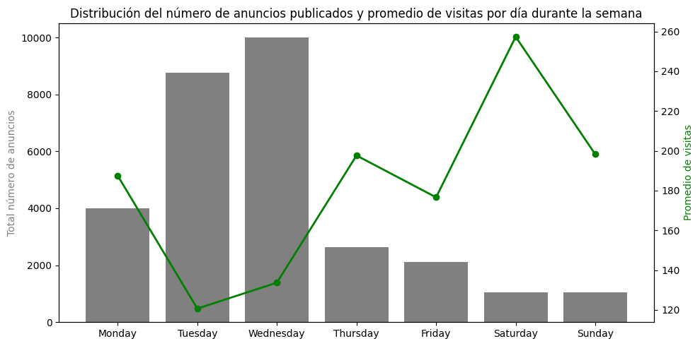

```python
order = ['Monday', 'Tuesday', 'Wednesday', 'Thursday', 'Friday', 'Saturday', 'Sunday']

df['publication_date'] = pd.to_datetime(df['publication_date'], errors='coerce', utc=True)
df['day_of_week'] = df['publication_date'].dt.day_name()

day_counts = df['day_of_week'].value_counts().reindex(order)
avg_views = (df.groupby('day_of_week')["statistics_views"].mean().reindex(order))

fig, ax1 = plt.subplots(figsize=(10, 5))

bars = ax1.bar(day_counts.index, day_counts.values, color='gray', label='Número de anuncios')
ax1.set_ylabel('Total número de anuncios', color='gray')
ax1.tick_params(axis='y')

ax2 = ax1.twinx()
ax2.plot(avg_views.index, avg_views.values, marker='o', linewidth=2, label='Promedio de visitas', color='green')
ax2.set_ylabel('Promedio de visitas', color='green')
ax2.tick_params(axis='y')

plt.title('Distribución del número de anuncios publicados y promedio de visitas por día durante la semana')
plt.xticks(rotation=45)
plt.tight_layout()
plt.show()
```

## 10. Coeficiente financiero de cada financiera a 120 meses

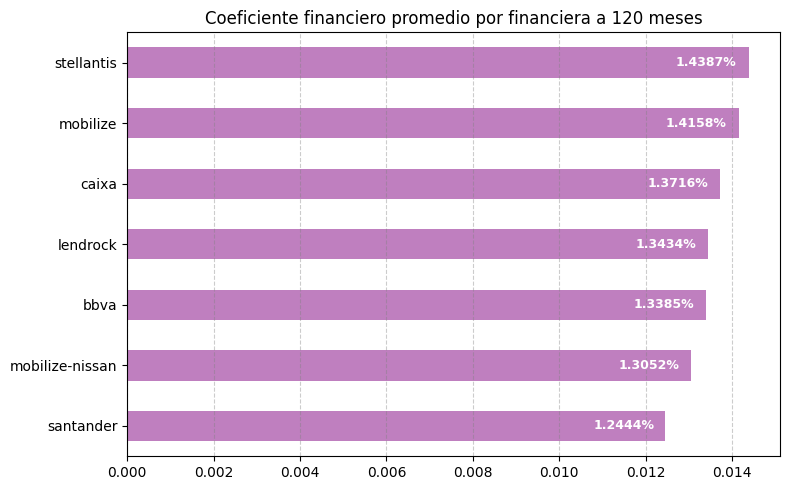

```python
coef_grouped = df[df['financing_terms'] == 120]
df_coef = coef_grouped.groupby('financing_lender')['financing_coefficient'].mean().sort_values()

plt.figure(figsize=(8, 5))
bars = df_coef.plot(kind='barh', color='purple', alpha=0.5)

for i, (lender, value) in enumerate(df_coef.items()):
    plt.text(value - value * 0.02, i, f"{value*100:.4f}%", va='center', ha='right', color='white', fontsize=9, fontweight='bold')

plt.title('Coeficiente financiero promedio por financiera a 120 meses')
plt.xlabel('')
plt.ylabel('')

plt.tight_layout()
plt.grid(axis='x', alpha=0.4, color='gray', linestyle='--')
plt.show()
```